# AE 25: Special topic: cryptanalysis

Your Name Here

2021-11-29

```r
library(tidyverse)
library(tidymodels)
library(reshape2)
```

# Bulletin

# Learning goals

By the end of today, you will…

- break a substitution cipher
- understand the intuition behind an algorithm to do so, *Markov chain Monte Carlo* (MCMC)

Our data includes

1. Complete text of “War and Peace” by Leo Tolstoy
2. Freq. analysis data frame of “War and Peace”
3. A secret message

This application exercise builds on the `R` code found [here](https://www.r-bloggers.com/2013/01/text-decryption-using-mcmc/) and [The Markov Chain Monte Carlo Revolution](https://math.uchicago.edu/~shmuel/Network-course-readings/MCMCRev.pdf) by Persi Diaconis.

Let’s load the data

```r
warandpeace = readLines("data/warandpeace.txt")
frequency = read.table("data/frequencies.txt")
colnames(frequency) = c(toupper(letters), "") # edit column names
secret_message = readLines("data/secret-message.txt")
```

## Exercise 1

Take a look at `secret-message`. Each letter is a stand in for exactly one other letter. This sort of cipher is known as a “substitution cipher”.

‘A’ could be encoded as one of 26 characters (A, B, C, …). Once the encoding for ‘A’ is chosen, ‘B’ has 25 possibilities and so on so there are, in total $26 \times 25 \times 24 \times \ldots \times 3 \times 2 \times 1$ possibilities.

```r
n = 26
input = n + 1
keys = gamma(input)
keys
```

```
## [1] 4.032915e+26
```

That’s over $4 \times 10^{26}$ possible keys! If you could check 10M keys per second, it would take approximately $1 \times 10^{12}$ years to check every possible key. Trying every possible key is known as a “brute force” approach.

Chat with your neighbor and develop a strategy better than the brute force approach. Detail your strategy below.

## Exercise 2

Here we determine how often one character follows another using the text from the very long book, War and Peace. We include a whitespace character as a 27th character in our alphabet.

The result of the below analysis is in the object `frequency`.

The `letter` column denotes the first character in a 2 character sequence while subsequent columns determine the second character in the character sequence.

- What should be the sum of a row? Check this for the first row of the data frame.

```r
# code here

# check one
sum(frequency[1,])
```

```
## [1] 1
```

```r
# check all
frequency %>%
  rowSums
```

```
## A B C D E F G H I J K L M N O P Q R S T U V W X Y Z
## 1 1 1 1 1 1 1 1 1 1 1 1 1 1 1 1 1 1 1 1 1 1 1 1 1 1 1
```

Create a [heatmap](https://ggplot2.tidyverse.org/reference/geom_bin_2d.html?q=heat#arguments) of character frequency, where the x-axis is the first letter and the y-axis is the second letter in a two letter chain.

Hint: use `melt` from the `reshape2` package. Click [here](http://www.sthda.com/english/wiki/ggplot2-quick-correlation-matrix-heatmap-r-software-and-data-visualization) for an example.

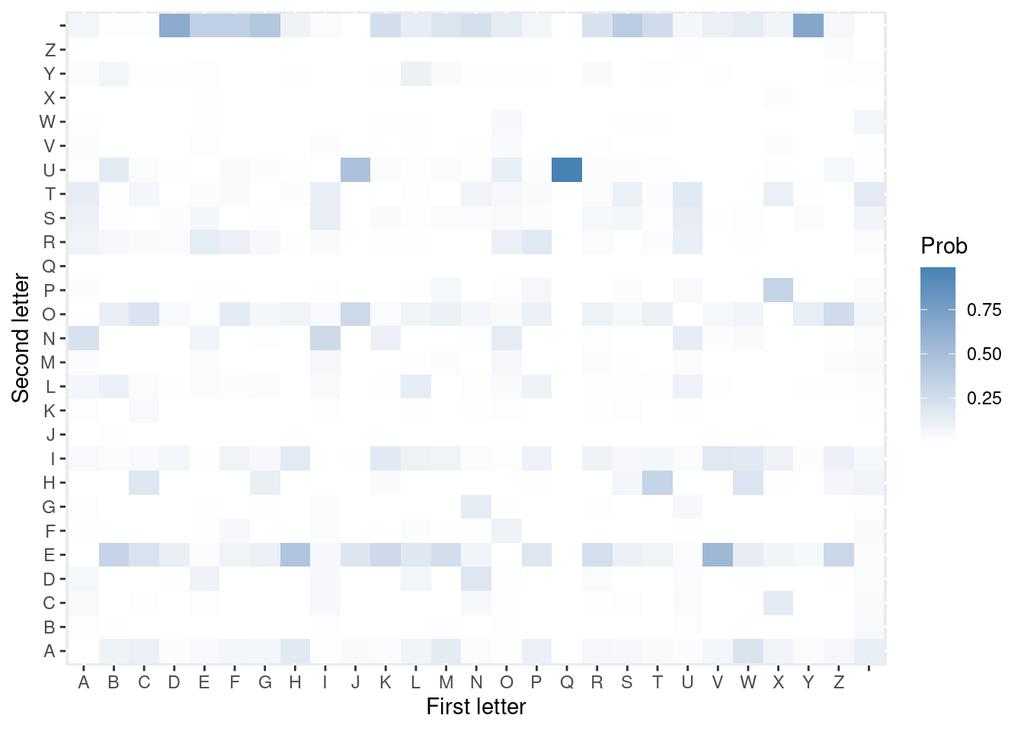

```r
melt_freq = melt(as.matrix(frequency))
# code here
melt_freq %>%
  ggplot(aes(x = Var1, y = Var2, fill = value)) +
  geom_tile() +
  labs(x = "First letter", y = "Second letter", fill = "Prob") +
  scale_fill_gradient(low="white", high = "steelblue")
```

## MCMC

We will use a famous statistical algorithm, Markov chain Monte Carlo (MCMC) to break the substitution cipher.

MCMC is composed of three essential components:

1. Ability. A way to propose any possible key.
2. Feedback. A way to evaluate how good a given key is.
3. Curiosity. A way to leave a good key for a worse key.

#### The analogy of the blind monkey.

There’s a monkey on an island with many ponds. The monkey has been tasked with finding the largest body of water on the island. The only trouble is, he is blind. In order to find the largest body of water, he throws rocks randomly and listens for a splash. If he hears a splash, he knows there’s a body of water where he last threw. He continues to throw more rocks in that direction to find out how big the pool is. Occasionally he gets bored and wanders off to look for another pond. In this way, he uses the MCMC algorithm to find the largest body of water.

#### Making the connection.

1. Ability (throw a rock). The Monkey can walk around and throw the rock anywhere on the island, ensuring that given enough time, he will cover every inch of the island.
2. Feedback (test for waters). Every time the Monkey throws the rock, he receives feedback by listening for a splash. A large splash means a deep pond and encourages him to continue throwing in that direction to figure out the perimeter of the pond.
3. Curiosity (boredom). If the monkey finds the second largest pond on the island, he might get stuck throwing rocks in it for a long time. By occasionally walking away from a large pond, he will reach the largest pond quicker.

## Exercise 3

Let’s write out together what MCMC looks like when decrpyting a secret message.

1. Ability to traverse key space – we propose a letter mapping and then swap two letters to create a new proposed mapping.
2. Feedback – use frequency analysis to determine how likely a given key is.
3. Curiosity – compare proposed key to current key. If new key is better then accept the letter swap and if it is worse, flip a coin to decide whether you accept or reject the swap.

## Exercise 4

Here we load some functions that will help us decode the message.

```r
trans.prob.mat = frequency

trans.mat = matrix(0, 27, 27)
rownames(trans.mat) = colnames(trans.mat) = c(toupper(letters), "")

decode <- function(mapping, coded) {
  coded = toupper(coded)
  decoded = coded
  for (i in 1:nchar(coded)) {
    if (substring(coded, i, i) %in% toupper(letters)) {
      substring(decoded, i, i) = toupper(letters[mapping == substring(coded, i, i)])
    }
  }
  decoded
}


log.prob <- function(mapping, decoded) {
  logprob = 0

  lastletter = ""
  for (i in 1:nchar(decoded)) {
    curletter = substring(decoded, i, i)
    if (curletter %in% toupper(letters)) {
      logprob = logprob + log(trans.prob.mat[rownames(trans.mat) == lastletter,
                                             colnames(trans.mat) == curletter])
      lastletter = curletter
    } else {
      if (lastletter != "") {
        logprob = logprob + log(trans.prob.mat[rownames(trans.mat) == lastletter, 27])
        lastletter = ""
      }
    }
  }

  if (lastletter != "") {
    logprob = logprob + log(trans.prob.mat[rownames(trans.mat) == lastletter, 27])
    lastletter = ""
  }
  logprob
}
```

Run the code below to break the secret message. If the message is unintelligble after several iterations, you may try re-starting with a new seed. What is this equivalent to in the monkey analogy above?

```r
set.seed(6)
coded = secret_message
mapping = sample(toupper(letters)) # initialize a random mapping
i = 1
iters = 300
mcmcAttack = function(coded) {
  cur.decode = decode(mapping, coded)
  cur.loglike = log.prob(mapping, cur.decode)
  max.loglike = cur.loglike
  max.decode = cur.decode
  while (i <= iters) {
    proposal = sample(1:26, 2) # select 2 letters to switch
    prop.mapping = mapping
    prop.mapping[proposal[1]] = mapping[proposal[2]]
    prop.mapping[proposal[2]] = mapping[proposal[1]]

    prop.decode = decode(prop.mapping, coded)
    prop.loglike = log.prob(prop.mapping, prop.decode)

    if (runif(1) < exp(prop.loglike - cur.loglike)) {
      mapping = prop.mapping
      cur.decode = prop.decode
      cur.loglike = prop.loglike

      if (cur.loglike > max.loglike) {
        max.loglike = cur.loglike
        max.decode = cur.decode
      }

      if (i %% 25 == 0) {
        cat(i, cur.decode, "\n")
      }
      i = i + 1
    }
  }
  cat("best guess: ", max.decode)
}

mcmcAttack(coded)
```

```
## 25 ORTOL FUKNOT FUK TA MO AL RAT TA MO TFUT GI TFO CEOITGAR DFOTFOL TGI RAMNOL GR TFO KGRS TA IEHHOL TFO INGRVI URS ULLADI AH AETLUVOAEI HALTERO AL TA TUXO ULKI UVUGRIT U IOU AH TLAEMNOI URS MY APPAIGRV ORS TFOK
## 50 ELTER HIMNET HIM TA KE AR LAT TA KE THIT OU THE WSEUTOAL GHETHER TOU LAKNER OL THE MOLY TA USPPER THE UNOLDU ILY IRRAGU AP ASTRIDEASU PARTSLE AR TA TIZE IRMU IDIOLUT I UEI AP TRASKNEU ILY KC AFFAUOLD ELY THEM
## 75 ENTER HAYUET HAY TO BE OR NOT TO BE THAT IL THE MSELTION ZHETHER TIL NOBUER IN THE YIND TO LSPPER THE LUINGL AND ARROZL OP OSTRAGEOSL PORTSNE OR TO TAWE ARYL AGAINLT A LEA OP TROSBUEL AND BV OCCOLING END THEY
## 100 ENTER HAYBET HAY TO ME OR NOT TO ME THAT IS THE CUESTION WHETHER TIS NOMBER IN THE YIND TO SUFFER THE SBINGS AND ARROWS OF OUTRAGEOUS FORTUNE OR TO TALE ARYS AGAINST A SEA OF TROUMBES AND MP OZZOSING END THEY
## 125 ENTER HAYBET HAY TO ME OR NOT TO ME THAT IS THE JUESTION WHETHER TIS NOMBER IN THE YIND TO SULLER THE SBINGS AND ARROWS OL OUTRAGEOUS LORTUNE OR TO TAVE ARYS AGAINST A SEA OL TROUMBES AND MP OFFOSING END THEY
## 150 ENTER HAYPET HAY TO ME OR NOT TO ME THAT IS THE QUESTION WHETHER TIS NOMPER IN THE YIND TO SUFFER THE SPINGS AND ARROWS OF OUTRAGEOUS FORTUNE OR TO TAVE ARYS AGAINST A SEA OF TROUMPES AND MB OCCOSING END THEY
## 175 ENTER HAYPET HAY TO ME OR NOT TO ME THAT IS THE KUESTION WHETHER TIS NOMPER IN THE YIND TO SUFFER THE SPINGS AND ARROWS OF OUTRAGEOUS FORTUNE OR TO TAVE ARYS AGAINST A SEA OF TROUMPES AND MB OLLOSING END THEY
## 200 ENTER HALBET HAL TO ME OR NOT TO ME THAT IS THE JUESTION WHETHER TIS NOMBER IN THE LIND TO SUFFER THE SBINGS AND ARROWS OF OUTRAGEOUS FORTUNE OR TO TAKE ARLS AGAINST A SEA OF TROUMBES AND MY OPPOSING END THEL
## 225 ENTER HALPET HAL TO ME OR NOT TO ME THAT IS THE JUESTION WHETHER TIS NOMPER IN THE LING TO SUFFER THE SPINDS ANG ARROWS OF OUTRADEOUS FORTUNE OR TO TACE ARLS ADAINST A SEA OF TROUMPES ANG MY OBBOSIND ENG THEL
## 250 ENTER HALPET HAL TO ME OR NOT TO ME THAT IS THE CUESTION WHETHER TIS NOMPER IN THE LIND TO SUFFER THE SPINGS AND ARROWS OF OUTRAGEOUS FORTUNE OR TO TAVE ARLS AGAINST A SEA OF TROUMPES AND MY OBBOSING END THEL
## 275 ENTER HALPET HAL TO ME OR NOT TO ME THAT IS THE QUESTION WHETHER TIS NOMPER IN THE LIND TO SUFFER THE SPINGS AND ARROWS OF OUTRAGEOUS FORTUNE OR TO TAVE ARLS AGAINST A SEA OF TROUMPES AND MY OZZOSING END THEL
## 300 ENTER HALPET HAL TO ME OR NOT TO ME THAT IS THE QUESTION WHETHER TIS NOMPER IN THE LING TO SUFFER THE SPINDS ANG ARROWS OF OUTRADEOUS FORTUNE OR TO TAVE ARLS ADAINST A SEA OF TROUMPES ANG MY OCCOSIND ENG THEL
## best guess:  ENTER HALPET HAL TO ME OR NOT TO ME THAT IS THE QUESTION WHETHER TIS NOMPER IN THE LIND TO SUFFER THE SPINGS AND ARROWS OF OUTRAGEOUS FORTUNE OR TO TAVE ARLS AGAINST A SEA OF TROUMPES AND MY OCCOSING END THEL
```

- Equivalent to starting from a different place on the island.

## Exercise 5

Try your own message!

Create your own message in the code below and call `mcmcAttack(coded)` on your message to decode it!

```r
set.seed(6)
correctTxt = "Oh somewhere in this favoured land the sun is shining bright The band is playing somewhere and somewhere hearts are light and somewhere men are laughing and somewhere children shout but there is no joy in Mudville mighty Casey has struck out"
coded = decode(sample(toupper(letters)), correctTxt)
mcmcAttack(coded)
```

```
## 25 IS YIFTWSTUT HE KSHY MBVILUTO RBEO KST YLE HY YSHEHED JUHDSK KST JBEO HY PRBNHED YIFTWSTUT BEO YIFTWSTUT STBUKY BUT RHDSK BEO YIFTWSTUT FTE BUT RBLDSHED BEO YIFTWSTUT ASHROUTE YSILK JLK KSTUT HY EI GIN HE FLOVHRRT FHDSKN ABYTN SBY YKULAC ILK
## 50 US AUCTWSTOT HE KSHA PIGULOTY RIEY KST ALE HA ASHEHEM FOHMSK KST FIEY HA BRINHEM AUCTWSTOT IEY AUCTWSTOT STIOKA IOT RHMSK IEY AUCTWSTOT CTE IOT RILMSHEM IEY AUCTWSTOT DSHRYOTE ASULK FLK KSTOT HA EU QUN HE CLYGHRRT CHMSKN DIATN SIA AKOLDV ULK
## 75 US OUCTWSTAT HE MSHO VIGULATD RIED MST OLE HO OSHEHEY BAHYSM MST BIED HO PRINHEY OUCTWSTAT IED OUCTWSTAT STIAMO IAT RHYSM IED OUCTWSTAT CTE IAT RILYSHEY IED OUCTWSTAT KSHRDATE OSULM BLM MSTAT HO EU QUN HE CLDGHRRT CHYSMN KIOTN SIO OMALKF ULM
## 100 US OUCTWSTAT HE KSHO VIGULATD RIED KST OLE HO OSHEHEY BAHYSK KST BIED HO FRINHEY OUCTWSTAT IED OUCTWSTAT STIAKO IAT RHYSK IED OUCTWSTAT CTE IAT RILYSHEY IED OUCTWSTAT MSHRDATE OSULK BLK KSTAT HO EU JUN HE CLDGHRRT CHYSKN MIOTN SIO OKALMP ULK
## 125 US OUCTRSTAT HE MSHO VIGULATD WIED MST OLE HO OSHEHEY PAHYSM MST PIED HO BWINHEY OUCTRSTAT IED OUCTRSTAT STIAMO IAT WHYSM IED OUCTRSTAT CTE IAT WILYSHEY IED OUCTRSTAT KSHWDATE OSULM PLM MSTAT HO EU JUN HE CLDGHWWT CHYSMN KIOTN SIO OMALKF ULM
## 150 US AUCTRSTOT HE MSHA VIGULOTD WIED MST ALE HA ASHEHEY BOHYSM MST BIED HA PWINHEY AUCTRSTOT IED AUCTRSTOT STIOMA IOT WHYSM IED AUCTRSTOT CTE IOT WILYSHEY IED AUCTRSTOT KSHWDOTE ASULM BLM MSTOT HA EU QUN HE CLDGHWWT CHYSMN KIATN SIA AMOLKF ULM
## 175 US OUCTRSTAT HE MSHO KIGULATD WIED MST OLE HO OSHEHEY PAHYSM MST PIED HO FWINHEY OUCTRSTAT IED OUCTRSTAT STIAMO IAT WHYSM IED OUCTRSTAT CTE IAT WILYSHEY IED OUCTRSTAT BSHWDATE OSULM PLM MSTAT HO EU QUN HE CLDGHWWT CHYSMN BIOTN SIO OMALBV ULM
## 200 US OUCTRSTAT HE MSHO ZIGULATD WIED MST OLE HO OSHEHEY PAHYSM MST PIED HO KWINHEY OUCTRSTAT IED OUCTRSTAT STIAMO IAT WHYSM IED OUCTRSTAT CTE IAT WILYSHEY IED OUCTRSTAT BSHWDATE OSULM PLM MSTAT HO EU JUN HE CLDGHWWT CHYSMN BIOTN SIO OMALBV ULM
## 225 UA OUCTWATST HE MAHO FIGULSTD RIED MAT OLE HO OAHEHEY BSHYAM MAT BIED HO PRINHEY OUCTWATST IED OUCTWATST ATISMO IST RHYAM IED OUCTWATST CTE IST RILYAHEY IED OUCTWATST VAHRDSTE OAULM BLM MATST HO EU QUN HE CLDGHRRT CHYAMN VIOTN AIO OMSLVK ULM
## 250 UA OUCTWATST HE MAHO JIGULSTD RIED MAT OLE HO OAHEHEY PSHYAM MAT PIED HO BRINHEY OUCTWATST IED OUCTWATST ATISMO IST RHYAM IED OUCTWATST CTE IST RILYAHEY IED OUCTWATST FAHRDSTE OAULM PLM MATST HO EU QUN HE CLDGHRRT CHYAMN FIOTN AIO OMSLFK ULM
## 275 UA OUCTWATST HE MAHO VIGULSTD RIED MAT OLE HO OAHEHEY BSHYAM MAT BIED HO PRINHEY OUCTWATST IED OUCTWATST ATISMO IST RHYAM IED OUCTWATST CTE IST RILYAHEY IED OUCTWATST FAHRDSTE OAULM BLM MATST HO EU QUN HE CLDGHRRT CHYAMN FIOTN AIO OMSLFK ULM
## 300 US OUCTRSTAT HE MSHO KIGULATD WIED MST OLE HO OSHEHEY BAHYSM MST BIED HO ZWINHEY OUCTRSTAT IED OUCTRSTAT STIAMO IAT WHYSM IED OUCTRSTAT CTE IAT WILYSHEY IED OUCTRSTAT PSHWDATE OSULM BLM MSTAT HO EU JUN HE CLDGHWWT CHYSMN PIOTN SIO OMALPF ULM
## best guess:  US OUCTRSTAT HE MSHO VIGULATD WIED MST OLE HO OSHEHEY BAHYSM MST BIED HO KWINHEY OUCTRSTAT IED OUCTRSTAT STIAMO IAT WHYSM IED OUCTRSTAT CTE IAT WILYSHEY IED OUCTRSTAT PSHWDATE OSULM BLM MSTAT HO EU QUN HE CLDGHWWT CHYSMN PIOTN SIO OMALPF ULM
```

You might think about what makes the message easy or difficult to attack, e.g. does length of the message affect its susceptibility to attack? What else might?

- Many things could affect susceptibility to attack. E.g. length of message, language, etc.